# Housing Prices Exploration

# by Derek Stratton

========================================================

### Abstract

My fiance and I are getting married next month and we’re in the process of searching for a new home for our future family. There are many factors to consider when purchasing a new home, a few of them being: price, location, future value, school districts, and safety. Although this data does not pertain to the city in which we are house hunting, the exploration process should provide valuable insight into what factors have the biggest influence on the price of a home.

### Resources

Downloaded dataset from: https://www.kaggle.com/harlfoxem/housesalesprediction

This dataset contains house sale prices in King County, Washington between May 2014 to May 2015.

Other resources used:

http://ggplot2.tidyverse.org/reference/

http://bbs.ceb-institute.org/wp-content/uploads/2011/09/handout_ggplot2.pdf

http://www.cookbook-r.com/Graphs/Bar_and_line_graphs_(ggplot2)/

https://s3.amazonaws.com/udacity-hosted-downloads/ud651/ GeographyOfAmericanMusic.html

https://s3.amazonaws.com/content.udacity-data.com/courses/ud651/ diamondsExample_2016-05.html

https://s3.amazonaws.com/udacity-hosted-downloads/ud651/ AtlanticHurricaneTracking.html

https://github.com/Shreyas3108/house-price-prediction/blob/master/ housesales.ipynb

https://www.rstudio.com/wp-content/uploads/2015/03/ggplot2-cheatsheet.pdf

http://www.sthda.com/english/wiki/ggplot2-scatter-plots-quick-start-guide -r-software-and-data-visualization

### Dataset Preparations

library(ggplot2) library(knitr) library(dplyr) library(maps) options(scipen=999)

## Univariate Plots Section

```r
names(houses_data)
```

```
##  [1] "id"            "date"          "price"         "bedrooms"
##  [5] "bathrooms"     "sqft_living"   "sqft_lot"      "floors"
##  [9] "waterfront"    "view"          "condition"     "grade"
## [13] "sqft_above"    "sqft_basement" "yr_built"      "yr_renovated"
## [17] "zipcode"       "lat"           "long"          "sqft_living15"
## [21] "sqft_lot15"
```

### Variable Observations & Analysis:

There are a total of 21 variables within the dataset. The “yr_built” variable is nice to know because buying an older home, although sometimes less expensive than alternatives, may unearth unwanted repairs and remodeling, resulting in more money spent and more stress as a new homeowner. I also will be creating an “age” variable based on the “yr_built” because it will be easier to understand.

Location is a strong factor for us so the “zipcode”, “lat”, and “long” variables are very interesting to me. I’d like to explore ways of using these values within a plot to visually see where the most and least expensive homes are located.

Overall, all of the variables are of interest me.

```r
str(houses_data)
```

```
## 'data.frame':    3000 obs. of  21 variables:
##  $ id           : num  7129300520 6414100192 5631500400 2487200875 1954400510 ...
##  $ date         : Factor w/ 308 levels "20140502T000000",..: 136 182 242 182 235 8 50 210 280 254 ...
##  $ price        : num  221900 538000 180000 604000 510000 ...
##  $ bedrooms     : int  3 3 2 4 3 4 3 3 3 3 ...
##  $ bathrooms    : num  1 2.25 1 3 2 4.5 2.25 1.5 1 2.5 ...
##  $ sqft_living  : int  1180 2570 770 1960 1680 5420 1715 1060 1780 1890 ...
##  $ sqft_lot     : int  5650 7242 10000 5000 8080 101930 6819 9711 7470 6560 ...
##  $ floors       : num  1 2 1 1 1 1 2 1 1 2 ...
##  $ waterfront   : int  0 0 0 0 0 0 0 0 0 0 ...
##  $ view         : int  0 0 0 0 0 0 0 0 0 0 ...
##  $ condition    : int  3 3 3 5 3 3 3 3 3 3 ...
##  $ grade        : int  7 7 6 7 8 11 7 7 7 7 ...
##  $ sqft_above   : int  1180 2170 770 1050 1680 3890 1715 1060 1050 1890 ...
##  $ sqft_basement: int  0 400 0 910 0 1530 0 0 730 0 ...
##  $ yr_built     : int  1955 1951 1933 1965 1987 2001 1995 1963 1960 2003 ...
##  $ yr_renovated : int  0 1991 0 0 0 0 0 0 0 0 ...
##  $ zipcode      : int  98178 98125 98028 98136 98074 98053 98003 98198 98146 98038 ...
##  $ lat          : num  47.5 47.7 47.7 47.5 47.6 ...
##  $ long         : num  -122 -122 -122 -122 -122 ...
##  $ sqft_living15: int  1340 1690 2720 1360 1800 4760 2238 1650 1780 2390 ...
##  $ sqft_lot15   : int  5650 7639 8062 5000 7503 101930 6819 9711 8113 7570 ...
```

### Structure Observations & Analysis:

The structure of this dataset is a data frame and consists of 21 total variables, including 3 different data types: numeric, integer, and Factor. I already envisioned creating grouped distrbution graphs so I will be converting a few variables into Factors, such as “bedrooms”.

```r
summary(houses_data)
```

```
##        id                          date          price
##  Min.   :   1000102   20140625T000000:  25   Min.   :  75000
##  1st Qu.:2174325060   20140623T000000:  24   1st Qu.: 315000
##  Median :4015755246   20140723T000000:  23   Median : 445000
##  Mean   :4616355880   20140612T000000:  21   Mean   : 534515
##  3rd Qu.:7300402560   20140728T000000:  20   3rd Qu.: 640000
##  Max.   :9839300875   20140916T000000:  20   Max.   :5350000
##                       (Other)        :2867
##     bedrooms      bathrooms      sqft_living      sqft_lot
##  Min.   :0.00   Min.   :0.000   Min.   : 380   Min.   :    649
##  1st Qu.:3.00   1st Qu.:1.500   1st Qu.:1430   1st Qu.:   5502
##  Median :3.00   Median :2.000   Median :1910   Median :   8040
##  Mean   :3.39   Mean   :2.077   Mean   :2076   Mean   :  15333
##  3rd Qu.:4.00   3rd Qu.:2.500   3rd Qu.:2500   3rd Qu.:  11329
##  Max.   :8.00   Max.   :6.000   Max.   :8010   Max.   :1651359
##
##      floors       waterfront        view         condition
##  Min.   :1.00   Min.   :0.00   Min.   :0.000   Min.   :1.00
##  1st Qu.:1.00   1st Qu.:0.00   1st Qu.:0.000   1st Qu.:3.00
##  Median :1.00   Median :0.00   Median :0.000   Median :3.00
##  Mean   :1.44   Mean   :0.01   Mean   :0.245   Mean   :3.46
##  3rd Qu.:2.00   3rd Qu.:0.00   3rd Qu.:0.000   3rd Qu.:4.00
##  Max.   :3.50   Max.   :1.00   Max.   :4.000   Max.   :5.00
##
##      grade          sqft_above   sqft_basement     yr_built
##  Min.   : 3.000   Min.   : 380   Min.   :   0   Min.   :1900
##  1st Qu.: 7.000   1st Qu.:1200   1st Qu.:   0   1st Qu.:1950
##  Median : 7.000   Median :1550   Median :   0   Median :1970
##  Mean   : 7.621   Mean   :1769   Mean   : 307   Mean   :1968
##  3rd Qu.: 8.000   3rd Qu.:2160   3rd Qu.: 600   3rd Qu.:1990
##  Max.   :12.000   Max.   :6720   Max.   :2600   Max.   :2015
##
##   yr_renovated        zipcode           lat             long
##  Min.   :   0.00   Min.   :98001   Min.   :47.18   Min.   :-122.5
##  1st Qu.:   0.00   1st Qu.:98031   1st Qu.:47.46   1st Qu.:-122.3
##  Median :   0.00   Median :98059   Median :47.57   Median :-122.2
##  Mean   :  94.51   Mean   :98076   Mean   :47.56   Mean   :-122.2
##  3rd Qu.:   0.00   3rd Qu.:98117   3rd Qu.:47.68   3rd Qu.:-122.1
##  Max.   :2015.00   Max.   :98199   Max.   :47.78   Max.   :-121.3
##
##  sqft_living15    sqft_lot15
##  Min.   : 620   Min.   :   660
##  1st Qu.:1490   1st Qu.:  5460
##  Median :1840   Median :  7920
##  Mean   :1990   Mean   : 13270
##  3rd Qu.:2360   3rd Qu.: 10426
##  Max.   :5790   Max.   :425581
##
```

### Summary Observations & Analysis:

The first thing I wanted to try and identify using the summary was any outliers. Right off the bat I noticed the dataset contained records where there were values of zero for “bedrooms”. I definitely want to omit those before analyzing further. I also need to be mindful of what summary statistic is more appropriate to use - mean or median? Depending on my objective, there will be instances when the median is a better fit, especially if there are few records being compared.

### Initial Exploration

I discovered there were instances where homes had zero bedrooms. This sounds implausible and was probably due to input error, but at any rate, I want to remove these records.

```r
#find all instances when bedrooms is equal to zero
count(houses_data, bedrooms==0)
```

```
## # A tibble: 2 x 2
##   `bedrooms == 0`     n
##             <lgl> <int>
## 1           FALSE  2999
## 2            TRUE     1
```

It looks like there is only one home that contains zero bedrooms. I will now create a subset of the dataset that omits this instance.

```r
# remove all instances when bedrooms is equal to zero
homes <- subset(houses_data, bedrooms > 0)
```

The resulting dataframe has 2999 objects, which is the expected number since our original dataset contained 3000 objects and we were only omitting 1.

Now I want to convert the “yr_built” values into “age” because I think it’s an easier way to understand how old a home actually is.

```r
#add an "age" column by subtrating the yr_built from 2018
homes$age <- 2018 - homes$yr_built
```

Our new “homes” dataset now has a new numeric data-type variable called “age”.

Next, I will create a new “bedrooms” variable that is of Factor data-type because I will need it to fill in my distribution plots.

```r
#convert bedrooms column to Factor data type
homes$bedroom_count <- as.factor(homes$bedrooms)
```

The “homes” dataset now has a new Factor data-type variable called “bedroom_count”. This should allow me to use the “fill” functions when creating grouped distribution plots.

Let’s get some visuals about the ages of homes.

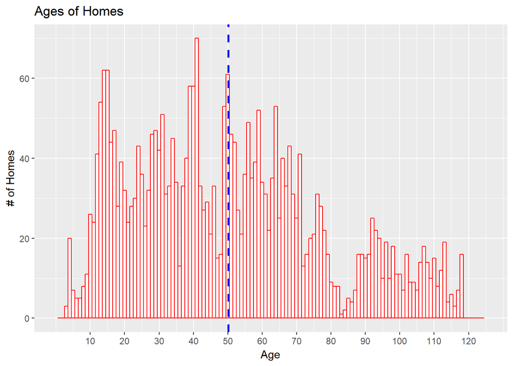

```r
#plot histogram of all the ages of homes
ggplot(data=homes, aes(x=age)) +
  geom_histogram(binwidth = 1, col = "red", fill="white") +
  labs(title="Ages of Homes") +
  labs(x="Age") +
  labs(y="# of Homes") +
  scale_x_continuous(limits=c(0,125), breaks=seq(10, 120, 10)) +
  geom_vline(aes(xintercept=mean(age, na.rm=T)),color="blue",
             linetype="dashed",size=1)
```

The average age of the 2999 observed homes is 50, which is somewhat alarming because that may be a sign that remodeling and repairs are inevitable for our future home. However, the histogram looks like most of the homes fall to the left of the average line, which indicates a higher count of newer homes. Our ideal home is no more than 30 years old, so let’s see how many homes fall under that criteria.

```r
#find how many homes are 30 years old or youger
length(which(homes$age<=30))
```

```
## [1] 869
```

```r
length(which(homes$age>30))
```

```
## [1] 2130
```

```r
length(which(homes$age<=30)) + length(which(homes$age>30))
```

```
## [1] 2999
```

Well that’s not what I expected. The left tail of the histogram may contain the largest bins and seem more dense, but the right tail actually contains more homes because the tail itself is wider. This is disappointing because the chances of us finding a home that’s within our desired age is less likely and we will most likely end up having to spend more money on remodeling and repairs. Maybe that’s not such a bad thing. As long as the home prices are reasonably less expensive compared to the newer homes, the difference in price could cover the additional remodeling and repair costs. I’ll explore this idea in the next section.

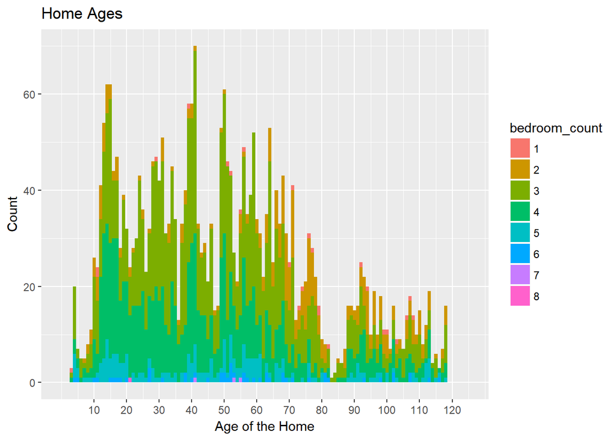

```r
#plot histogram of all the ages of homes but now group by the number of
#bedrooms
ggplot(homes) +
  geom_histogram(aes(age, fill=bedroom_count), binwidth=1) +
  scale_x_continuous(limits=c(0,125), breaks=seq(10, 120, 10)) +
  labs(x='Age of the Home', y='Count', title='Home Ages')
```

It looks like most of the homes have between 2-4 bedrooms, which is great because we are looking for a 2-3 bedroom home.

Now let’s explore the prices of homes.

```r
#find range of home prices and summary of home prices
range(homes$price)
```

```
## [1]   75000 5350000
```

```r
summary(homes$price)
```

```
##    Min. 1st Qu.  Median    Mean 3rd Qu.    Max.
##   75000  315000  445000  534326  639500 5350000
```

```r
mean(homes$price)
```

```
## [1] 534326.3
```

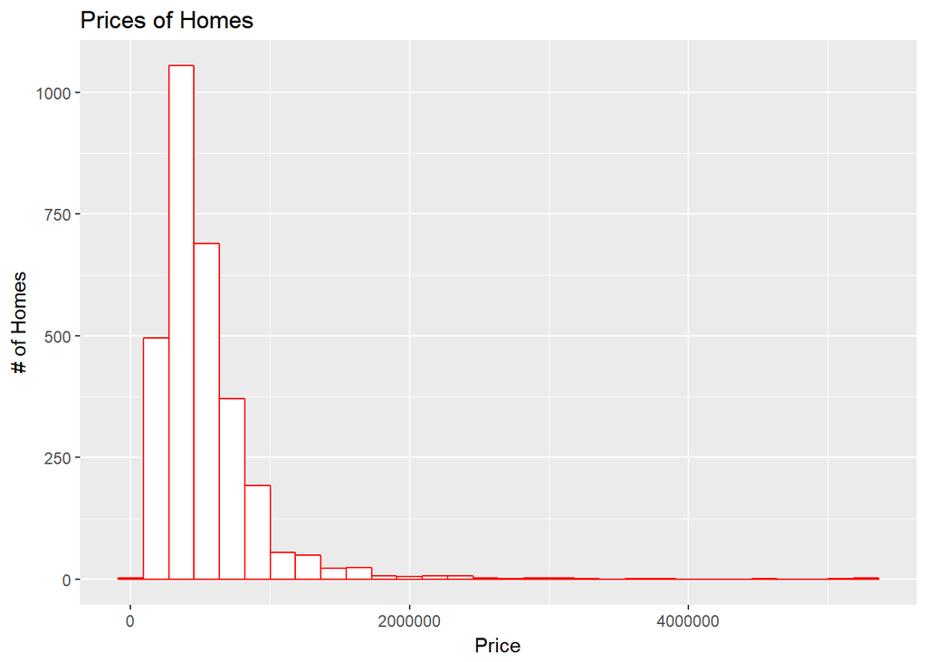

```r
#plot the prices of all the homes
ggplot(data=homes, aes(x=price)) +
  geom_histogram(col = "red", fill="white") +
  labs(title="Prices of Homes", x="Price", y="# of Homes")
```

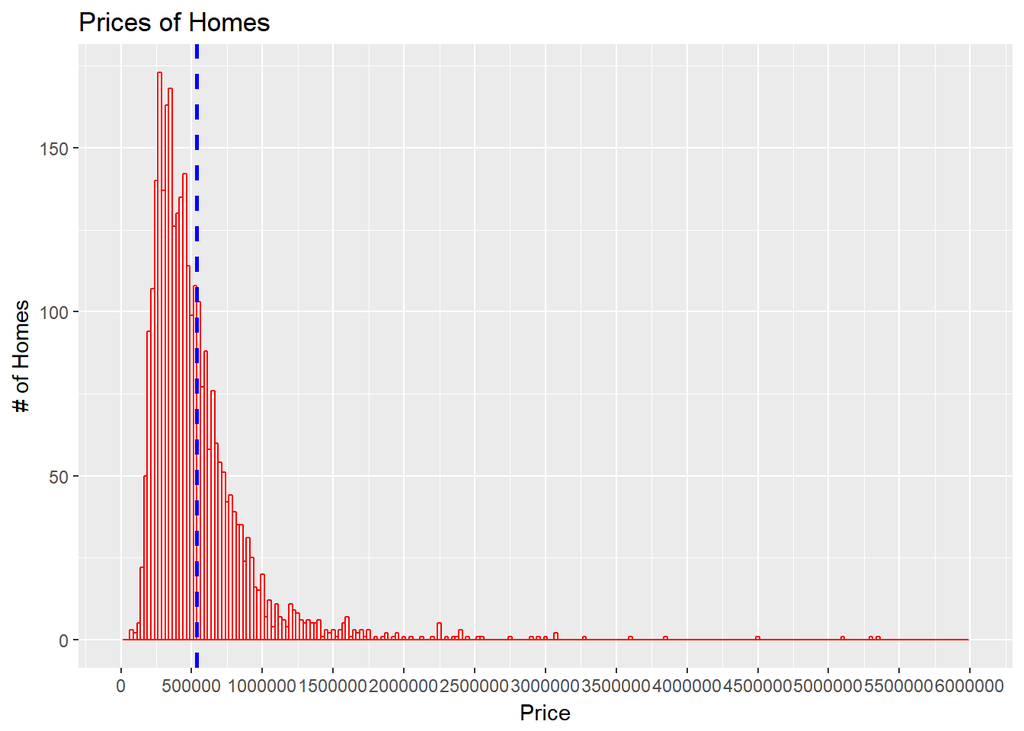

```r
#lets get a better look at this distrubution
ggplot(data=homes, aes(x=price)) +
  geom_histogram(binwidth = 25000, col = "red", fill="white") +
  labs(title="Prices of Homes") +
  labs(x="Price") +
  labs(y="# of Homes") +
  scale_x_continuous(limits=c(0,6000000), breaks=seq(0, 6000000, 500000)) +
  geom_vline(aes(xintercept=mean(price, na.rm=T)),color="blue",
             linetype="dashed",size=1)
```

My first plot didn’t really give me much insight into the data so adjusting the binwidth and manipulating the x-axis allowed me to see that the distrubtion of prices is heavily right-skeweed. This is good news for me because our budget is between $600,000 - 650,000.

As I did before with the age of homes, I’d like to see the distribution of prices in relation to the number of bedrooms.

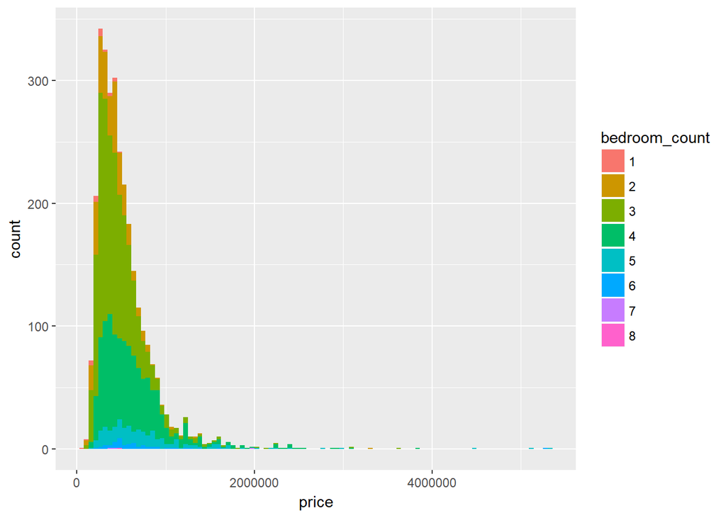

```r
#plot the prices of homes
ggplot(homes, aes(price, fill = bedroom_count)) +
  geom_histogram(bins = 100)
```

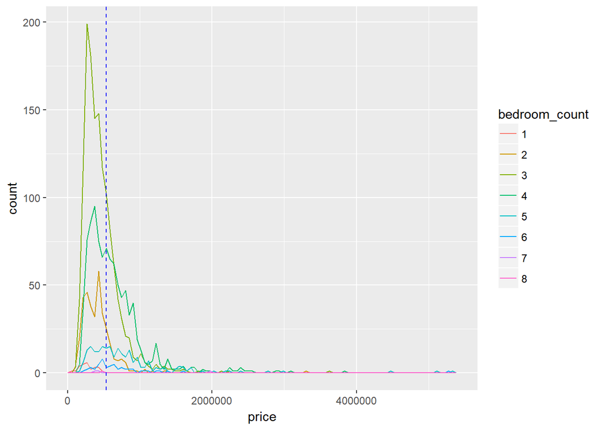

```r
ggplot(homes, aes(price, colour = bedroom_count)) +
  geom_freqpoly(bins = 100) +
  geom_vline(aes(xintercept=mean(price, na.rm=T)),color="blue",
             linetype="dashed",size=.5)
```

I really like the second plot because it allows me to clearly see that 3-bedroom homes are the most available and it falls below the average home price line of $534,326.

Now that I’ve looked at the distribution of prices, one variable that is not included in the original dataset but is highly used when determining the value of a home, is the price per square footage. Let’s create this variable.

```r
# create a new variable to shows how much the price per square footage is
homes$price_per_sqft <- homes$price / homes$sqft_living
```

Now that we have this variable, let’s plot it.

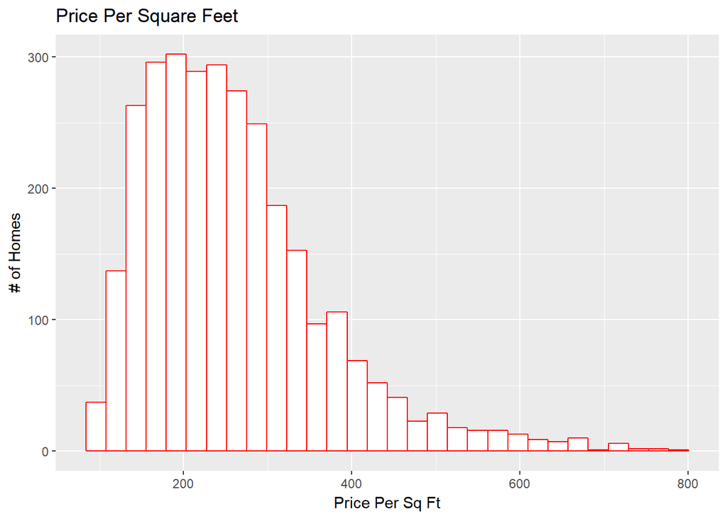

```r
#plot the price per square foot of all the homes
ggplot(data=homes, aes(x=price_per_sqft)) +
  geom_histogram(col = "red", fill="white") +
  labs(title="Price Per Square Feet", x="Price Per Sq Ft", y="# of Homes")
```

As expected, the shape of this distribution is also right-skewed just like the price histogram.

## Bivariate Plot Section

The main purpose of this exploration is to determine what variable has the most influence on the price of a home. Earlier I mentioned several different factors. Now I will explore the relationship between a few.

### Price vs Square Feet of Living Space

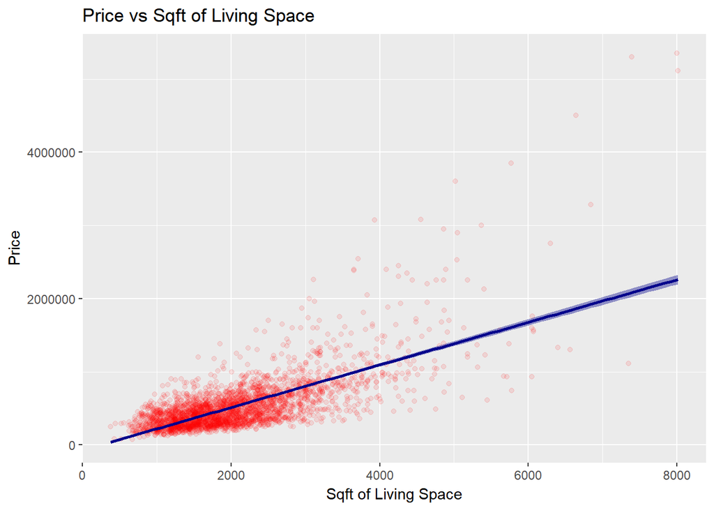

```r
# view the relationship using scatterplot
ggplot(aes(x = sqft_living, y = price), data = homes) +
  geom_point(color = "red", alpha = 1/10) +
  labs(title="Price vs Sqft of Living Space", x="Sqft of Living Space",
       y="Price") +
  stat_smooth(method = "lm", formula = y ~ x, size = 1, color = "darkblue",
              fill="darkblue")
```

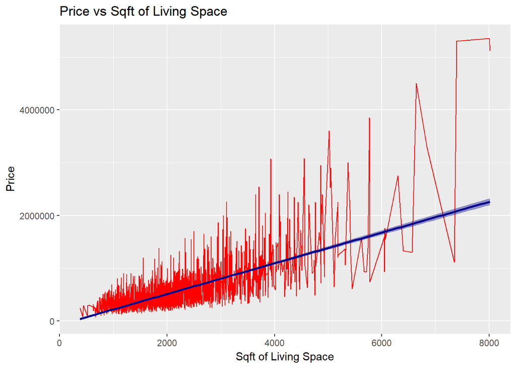

```r
# view relationship using line plot
ggplot(aes(x = sqft_living, y = price), data = homes) +
  geom_line(color = "red") +
  labs(title="Price vs Sqft of Living Space", x="Sqft of Living Space",
       y="Price") +
  stat_smooth(method = "lm", formula = y ~ x, size = 1, color = "darkblue",
              fill="darkblue")
```

```r
# perform a correlation test and see the results
cor.test(homes$price, homes$sqft_living, method = 'pearson')
```

```
##
##  Pearson's product-moment correlation
##
## data:  homes$price and homes$sqft_living
## t = 53.843, df = 2997, p-value < 0.00000000000000022
## alternative hypothesis: true correlation is not equal to 0
## 95 percent confidence interval:
##  0.6825490 0.7189588
## sample estimates:
##       cor
## 0.7012108
```

The relationship looks to be linear with a strong correlation coefficient of 0.70.

### Price vs Age

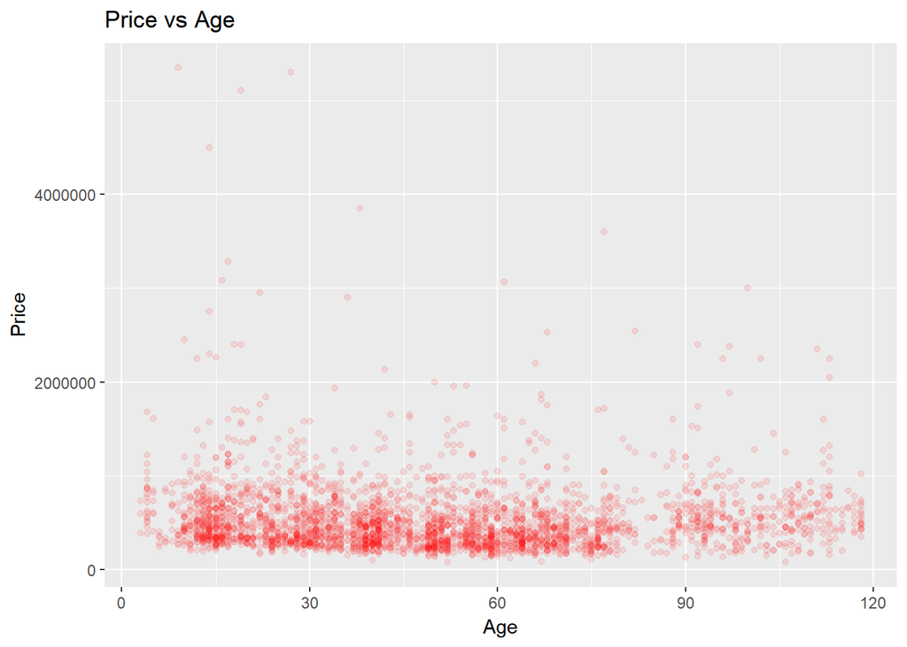

```r
# view the relationship using scatterplot
ggplot(aes(x = age, y = price), data = homes) +
  geom_point(color = "red", alpha = 1/10) +
  labs(title="Price vs Age", x="Age", y="Price")
```

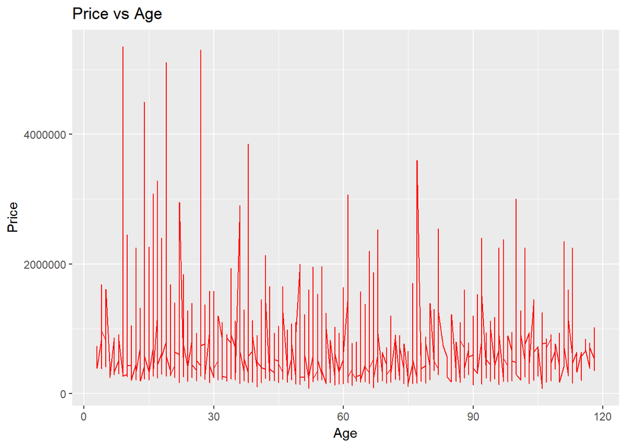

```r
# view relationship using line plot
ggplot(aes(x = age, y = price), data = homes) +
  geom_line(color = "red") +
  labs(title="Price vs Age", x="Age", y="Price")
```

```r
# perform a correlation test and see the results
cor.test(homes$price, homes$age, method = 'pearson')
```

```
##
##  Pearson's product-moment correlation
##
## data:  homes$price and homes$age
## t = -2.0602, df = 2997, p-value = 0.03946
## alternative hypothesis: true correlation is not equal to 0
## 95 percent confidence interval:
##  -0.073300520 -0.001816698
## sample estimates:
##         cor
## -0.03760672
```

It doesn’t look like there is any linear relationship between age and price but it was interesting to see a somewhat large concentration of homes hovering around the average home price but span across a wide age range: 15-60 years old.

### Price vs Location, Based on Zip Code

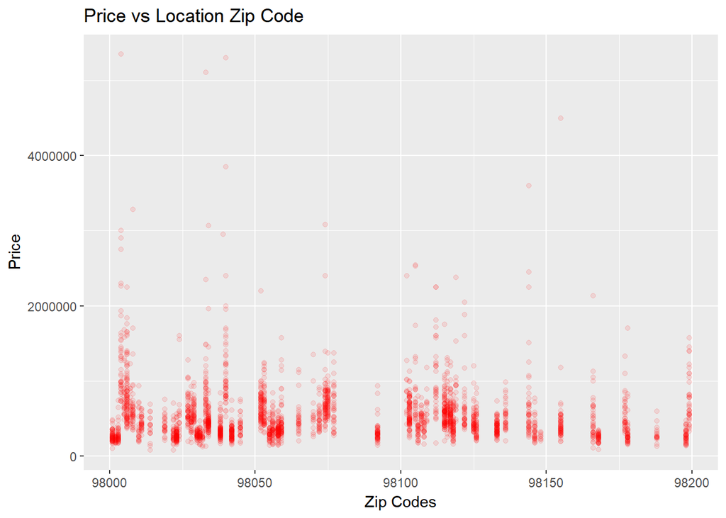

```r
# view the relationship using scatterplot
ggplot(aes(x = zipcode, y = price), data = homes) +
  geom_point(color = "red", alpha = 1/10) +
  labs(title="Price vs Location Zip Code", x="Zip Codes", y="Price")
```

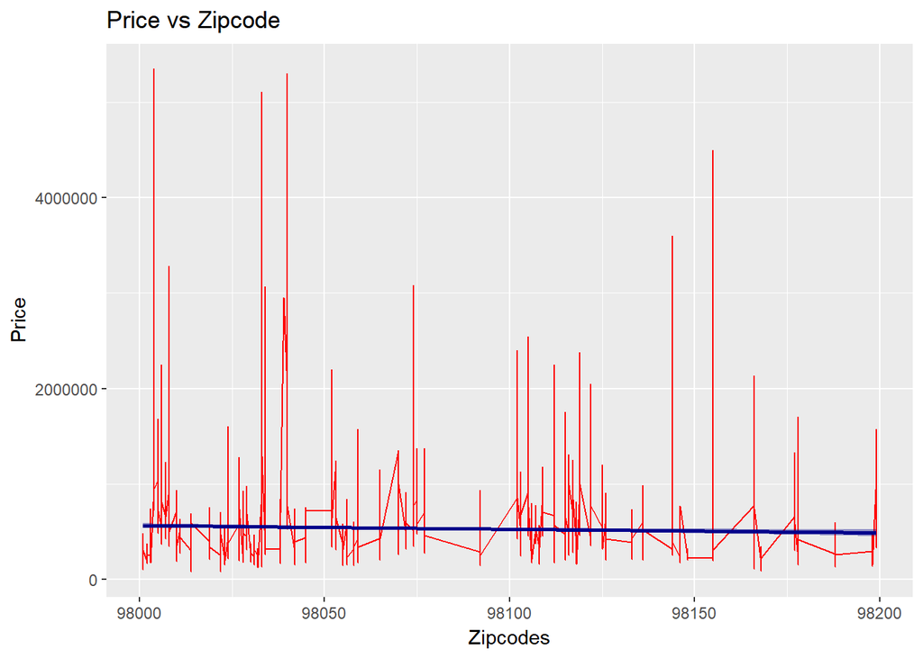

```r
# view relationship using line plot
ggplot(aes(x = zipcode, y = price), data = homes) +
  geom_line(color = "red") +
  labs(title="Price vs Zipcode", x="Zipcodes", y="Price") +
  stat_smooth(method = "lm", formula = y ~ x, size = 1, color = "darkblue",
              fill="darkblue")
```

```r
# perform a correlation test and see the results
cor.test(homes$price, homes$zipcode, method = 'pearson')
```

```
##
##  Pearson's product-moment correlation
##
## data:  homes$price and homes$zipcode
## t = -2.9618, df = 2997, p-value = 0.003082
## alternative hypothesis: true correlation is not equal to 0
## 95 percent confidence interval:
##  -0.08964209 -0.01826581
## sample estimates:
##         cor
## -0.05402296
```

### Average & Median Price vs Age

Next, I’d like to explore the average and median price of homes based on their age. Before doing so, I’d like to look into what statistic would be the most accurate to use when analyzing this type of relationship between grouped variables. Because the homes are grouped by age, I’m afraid that the average price of an age group with only a few samples could be distorted by outliers.

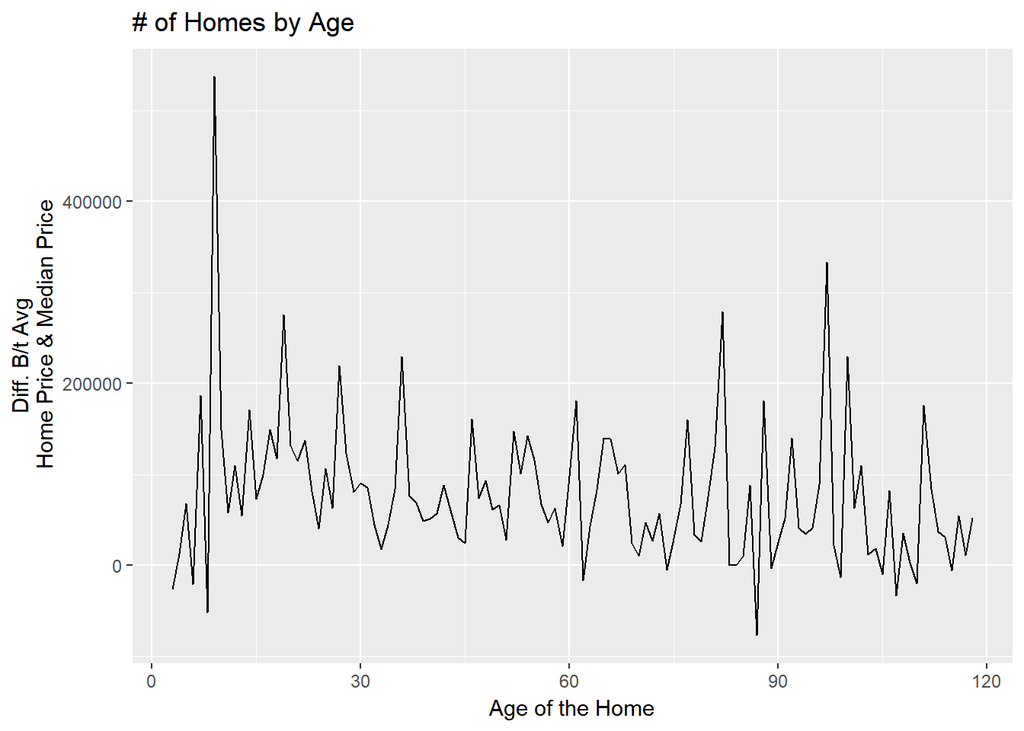

```r
#group the records by age
homes_by_age <- group_by(homes, age)

grouped_homes_by_age <- summarise(homes_by_age,
    avg_home_price = mean(price),
    median_home_price = median(price),
    diff_bt_avg_median = avg_home_price - median_home_price,
    n = n())

#graph the difference between the age's average and median home price
ggplot(aes(x = age, y = diff_bt_avg_median), data = grouped_homes_by_age) +
  geom_line() +
  labs(title = '# of Homes by Age', x = 'Age of the Home', y = 'Diff. B/t Avg
       Home Price & Median Price')
```

The point of analyzing the difference between the average age and median for the age groups was to see which statistic is a better representation of the sample. For example, age groups that have very few occurrences and a wide range between low and high prices, would be better off using the median rather than the average. For example, it looks like around age 10 there is a huge spike which represents a great difference between that age’s average and median.

It turns out that the highest peak in the graph belongs to homes that are 9 years old and out of 11 homes in the dataset that are of that age, there is one outlier that is distorting the average - a $5,350,000 home. For this reason, we will use the median price rather than the average price when analyzing the relationship between the prices of grouped variables.

Now that we’ve came to that conclusion, let’s look at the relationships.

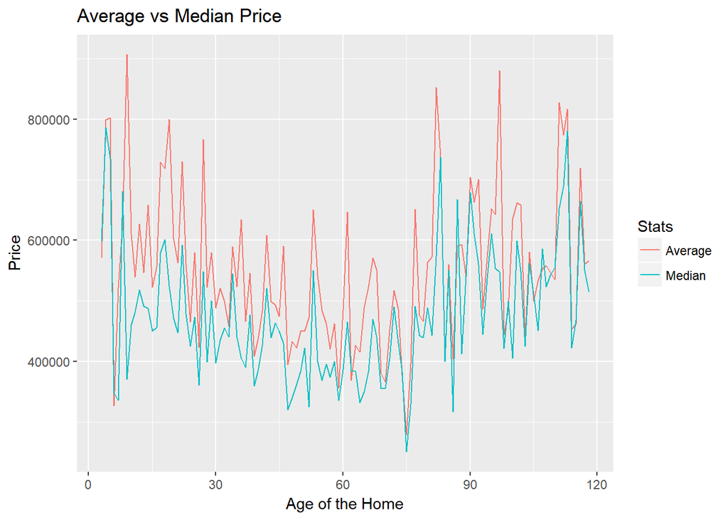

```r
#graph the average price by year and median price by year
ggplot(data=grouped_homes_by_age) +
  geom_line(aes(x = age, y = avg_home_price, colour = "Average")) +
  geom_line(aes(x = age, y = median_home_price, colour = "Median")) +
  labs(colour = "Stats", x='Age of the Home', y='Price',
       title='Average vs Median Price')
```

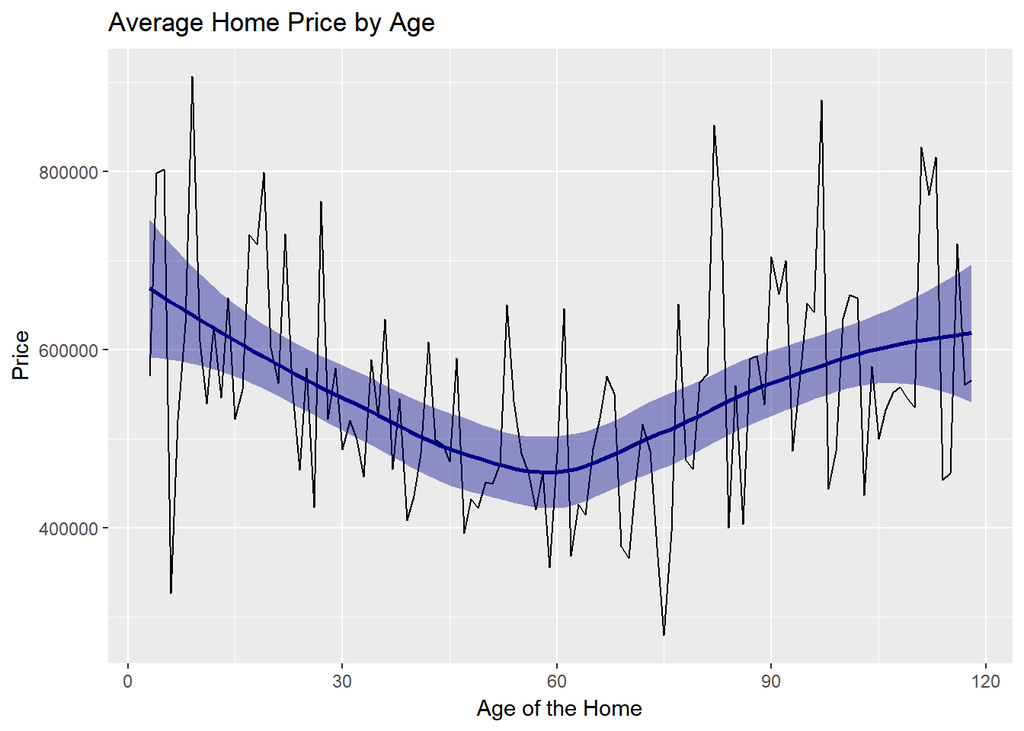

```r
ggplot(data=grouped_homes_by_age, aes(x = age, y = avg_home_price)) +
  geom_line() +
  labs(x='Age of the Home', y='Price', title='Average Home Price by Age') +
  stat_smooth(method = "loess", formula = y ~ x, size = 1, color = "darkblue",
              fill="darkblue")
```

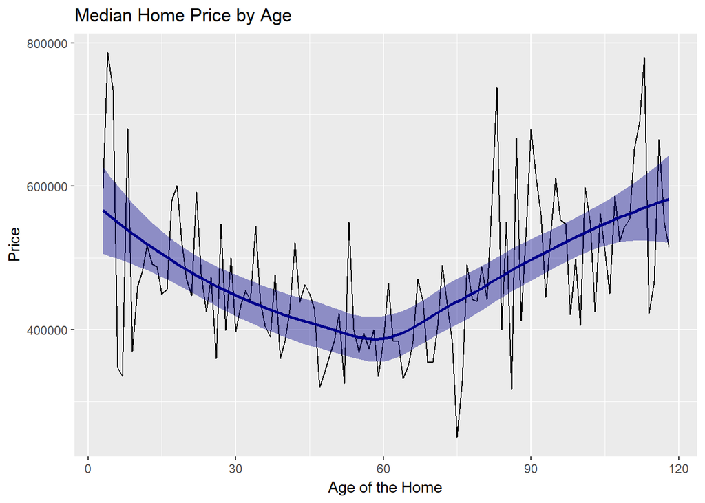

```r
ggplot(data=grouped_homes_by_age, aes(x = age, y = median_home_price)) +
  geom_line() +
  labs(x='Age of the Home', y='Price', title='Median Home Price by Age') +
  stat_smooth(method = "loess", formula = y ~ x, size = 1, color = "darkblue",
              fill="darkblue")
```

Based on our previous observation of “Price vs Age” and how the result was non-linear, I expected the average and median prices of the grouped ages to resemble a similar pattern. Interestingly, when I added the smoothed layer to each individual graph, the shape of the curve almost resembled an inverted bell-shape. Why is this occuring? One theory could be that the newer homes have a higher value because they’re just that - they are newer. And the older homes have a higher value because they could be considered “historic” and/or since they are so old, have since undergone a major remodel, thus increasing the home’s value. The dip in the curve could represent those homes that are stuck in the middle, where they aren’t considered quite new anymore but are still not old enough to warrant a full remodel. Let’s see if I can find out how many homes between the ages of 70 - 120 have been remodeled.

```r
# find how many homes were remodeled between the ages of 70-120 years old
length(which(homes$yr_renovated != 0 & homes$age > 69))
```

```
## [1] 99
```

```r
length(which(homes$age > 69))
```

```
## [1] 680
```

```r
99/680
```

```
## [1] 0.1455882
```

```r
length(which(homes$yr_renovated != 0 & homes$age < 51))
```

```
## [1] 16
```

```r
length(which(homes$age > 69))
```

```
## [1] 680
```

```r
16/680
```

```
## [1] 0.02352941
```

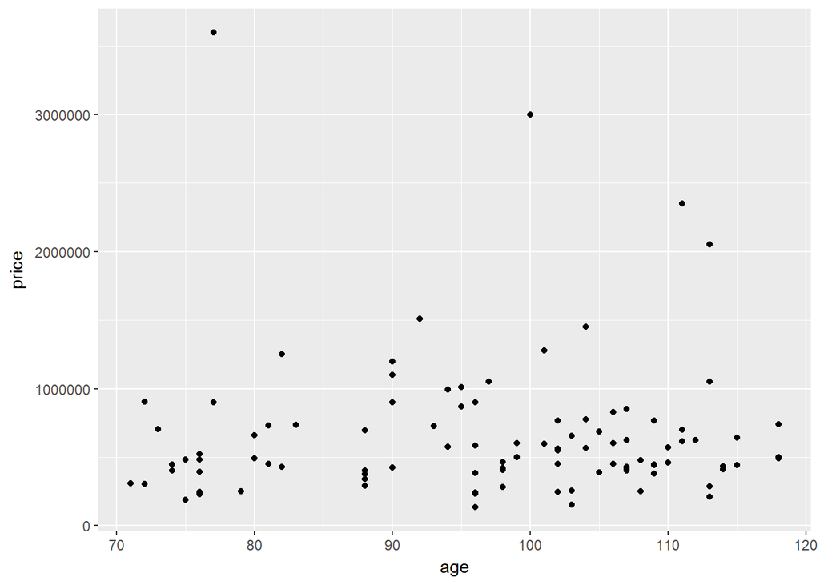

```r
#renoated homes that are at least 70 years old

ggplot(aes(x = age, y = price),
       data = subset(homes, homes$yr_renovated != 0 & homes$age > 69)) +
  geom_point()
```

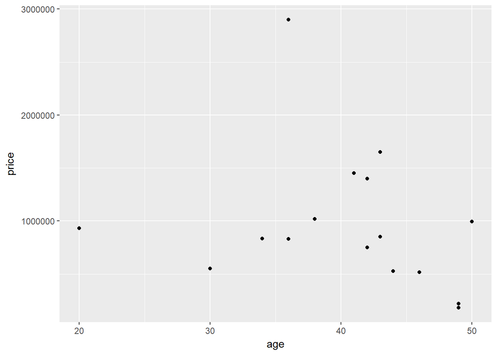

```r
#renovated homes that are no more than 50 years old

ggplot(aes(x = age, y = price),
       data = subset(homes, homes$yr_renovated != 0 & homes$age < 51)) +
  geom_point()
```

The scatterplots above clearly show that the majority of renovated homes are of the older kind.

### Median Price vs Month Sold

Moving along, like many industries, the housing market could experience their own seasonal affects where some periods generate more revenue than others. It would be smart to understand what time of year is the best to buy and sell. For that reason, I will now look at what months had the highest and lowest home prices for the year.

```r
#convert the 'date' column into a standard date format

homes$date1 <- substring(homes$date, 0, 8)

homes$date1 <- gsub("(^\\d{4})(\\d{2})(\\d{2}$)",
                                    "\\1-\\2-\\3", homes$date1)

homes$date1 <- format(as.Date(homes$date1), "%Y-%m")

#test out formating of dates

test <- '2014-10-13'

test2 <- months(as.Date(test))

test3 <- format(as.Date(test), "%Y-%m")
```

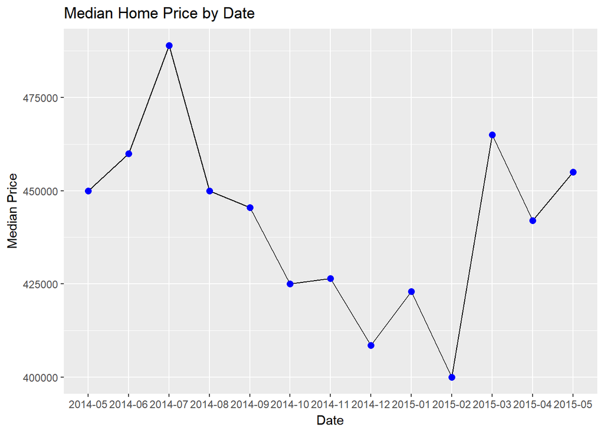

```r
#group the records by month
homes_by_month <- group_by(homes, date1)

grouped_homes_by_month <- summarise(homes_by_month,
    median_home_price = median(price),
    n = n())

#graph the median home price by month
ggplot(data=grouped_homes_by_month, aes(x = date1, y = median_home_price,
                                        group = 1)) +
  geom_line(stat="identity") +
  geom_point(shape=16, size=2, fill="red", colour="blue", stroke=1) +
  labs(x='Date', y='Median Price', title='Median Home Price by Date')
```

```r
  #stat_smooth(method = "loess", formula = y ~ x, size = 1, color = "darkblue", fill="darkblue")
```

Based on the graph, there is an upward trend from April to May of 2015 which could be an indication that home prices rise during the summer because the same trend can be seen in the prior year. This conclusion is still inconclusive because we don’t have enough date for prior or future years.

### Homes on a Map

Now that I’ve explored the relationship between date & price, age & price, and size & price, I will now look into the relationship between location and price.

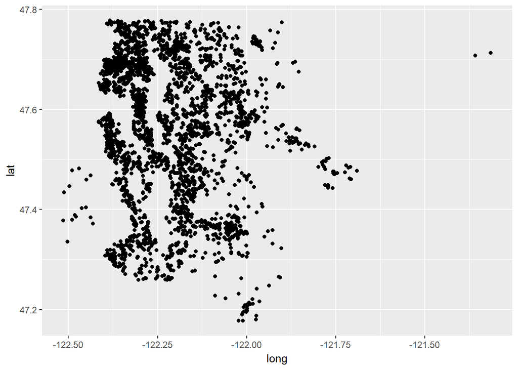

```r
#map out the location of the homes
ggplot(aes(x=long, y=lat), data=homes) +
    geom_point()
```

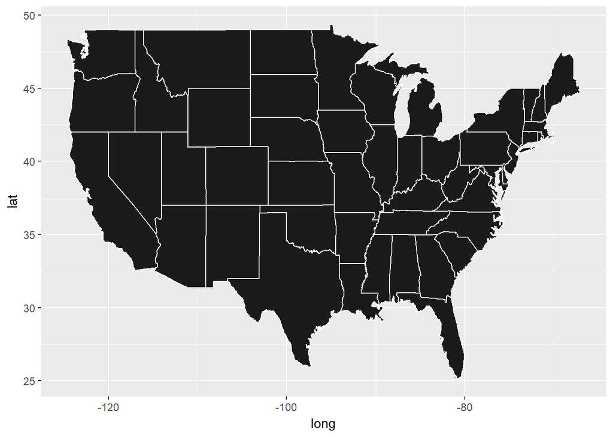

```r
map <- map_data("state")

ggplot(data=map) +
  geom_polygon(aes(x=long, y=lat, group = group),colour="white",
               fill="grey10")
```

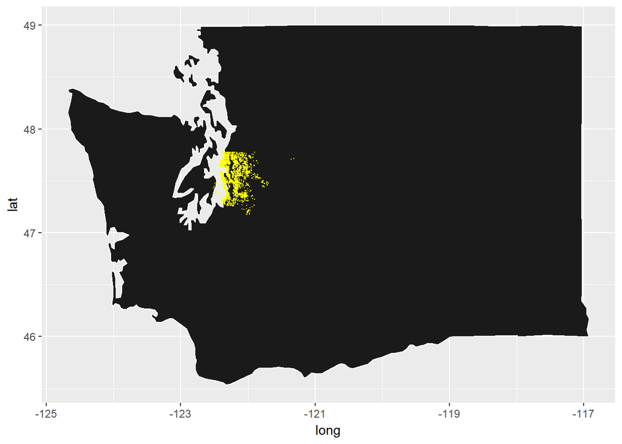

```r
washington <- subset(map, region %in% c("washington"))

ggplot(data=washington) +
  geom_polygon(aes(x=long, y=lat, group = group),colour="white",
      fill="grey10") + geom_jitter(data=homes, aes(x=long, y=lat),
      size = 1/10, color="yellow") + scale_size(name="Home Location")
```

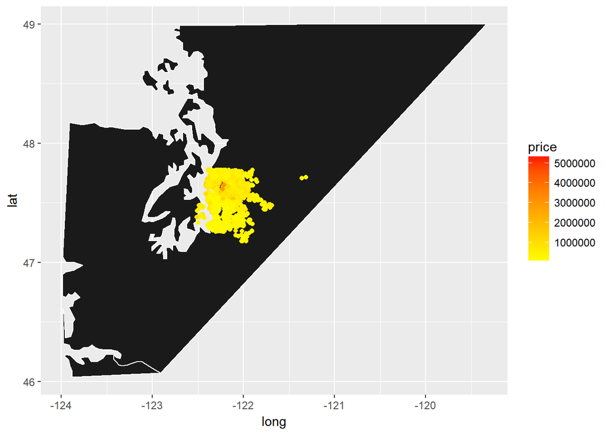

```r
washington_zoom <- subset(map, (long > -124 & long < -119) &
                            (lat > 46 & lat < 49))

ggplot(data=washington_zoom) +
  geom_polygon(aes(x=long, y=lat, group = group),colour="white",
        fill="grey10") +
  geom_point(data=homes, aes(x=long, y=lat, colour = price)) + scale_colour_gradient(low="yellow", high="red")
```

Even when switching color scales, the result still is an overwhelming majority of yellow because most of the homes have a price less than $1 million dollars.

## Multivariate Plots Section

In this section I will add an additional layer to the various “price” relationship graphs that I previously created.

### Price vs Sqft of Living Space Grouped by Bedroom Count

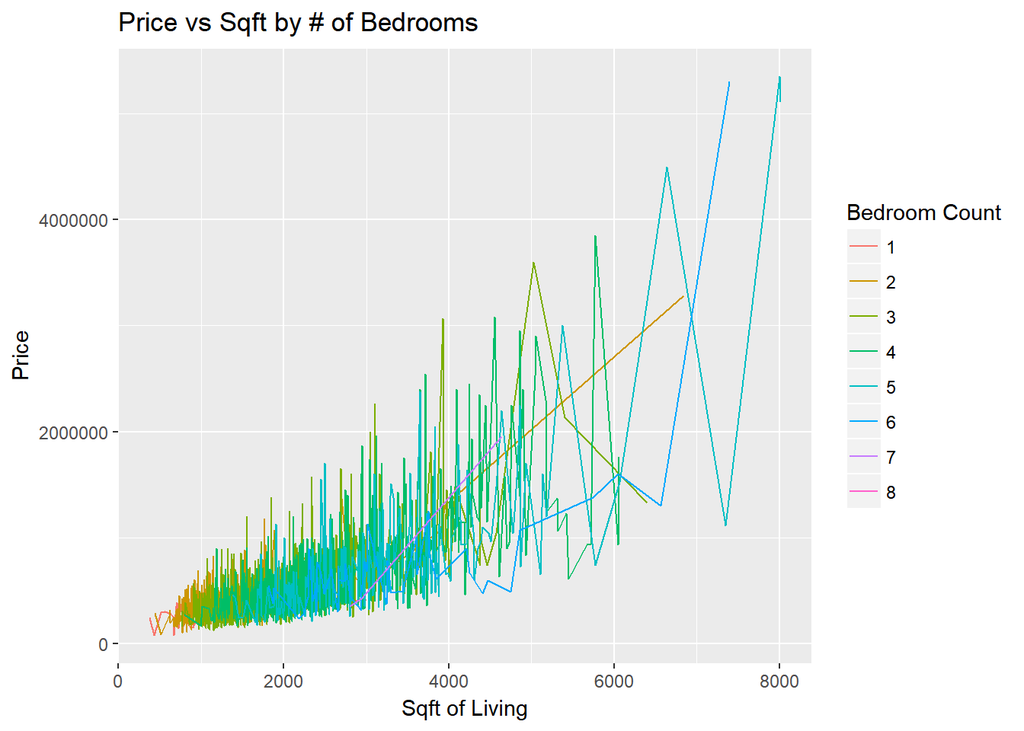

```r
# prce vs sqft_living grouped by bedroom count
ggplot(homes, aes(x=sqft_living, y=price, colour = bedroom_count)) +
  geom_line() +
  labs(colour = "Bedroom Count", title = "Price vs Sqft by # of Bedrooms",
       x = "Sqft of Living", y = "Price")
```

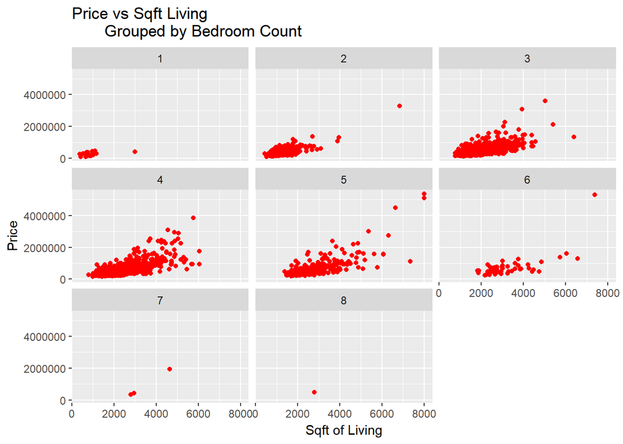

```r
ggplot(homes, aes(sqft_living, price)) +
  geom_point(color = "red") +
  facet_wrap(~bedrooms) +
  labs(x = "Sqft of Living", y = "Price", title = "Price vs Sqft Living
       Grouped by Bedroom Count")
```

As someone looking to start a family and grow into a house, the number of bedrooms is an important aspect to keep in mind. In our situation, we are planning to have 2-3 children so choosing between a 3 and 4 bedroom house is a big decision to make. But after looking at the results of the two plots, the decision might not be that hard. The plots for 3 and 4 bedrooms look almost identical. This tells me that the number of bedrooms does not have an affect on the price of the home, rather the square footage and size of the home is once again the biggest factor on price. A 2000 sqft 3-bedroom home could easily be the exact same price as a 2000 sqft 4-bedroom home. The difference could simply come down to how the square footage is divided. Does one home allocate more living space to bedrooms, hence sacrificing community and bathroom space? Does the other home do the opposite and create smaller rooms but increase the size of living rooms and bathrooms? It’s hard to say based off the information provided.

### A Look Into Activity by Month

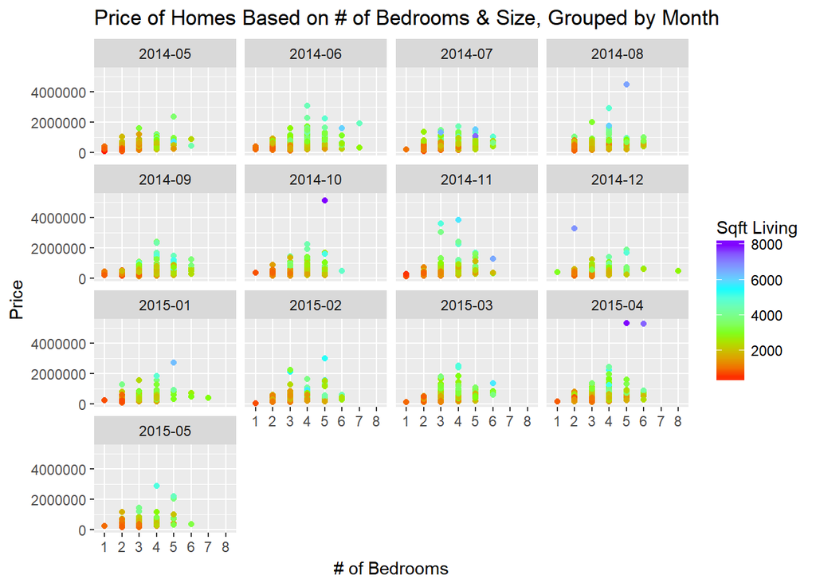

```r
ggplot(aes(x=bedroom_count,y=price),data=homes)+
  geom_point(aes(colour=sqft_living))+facet_wrap(~date1)+
  scale_colour_gradientn(colours=rainbow(4)) +
  labs(x = "# of Bedrooms", y = "Price", colour = "Sqft Living",
  title = "Price of Homes Based on # of Bedrooms & Size, Grouped by Month")
```

# Final Plots and Summary

### Plot One

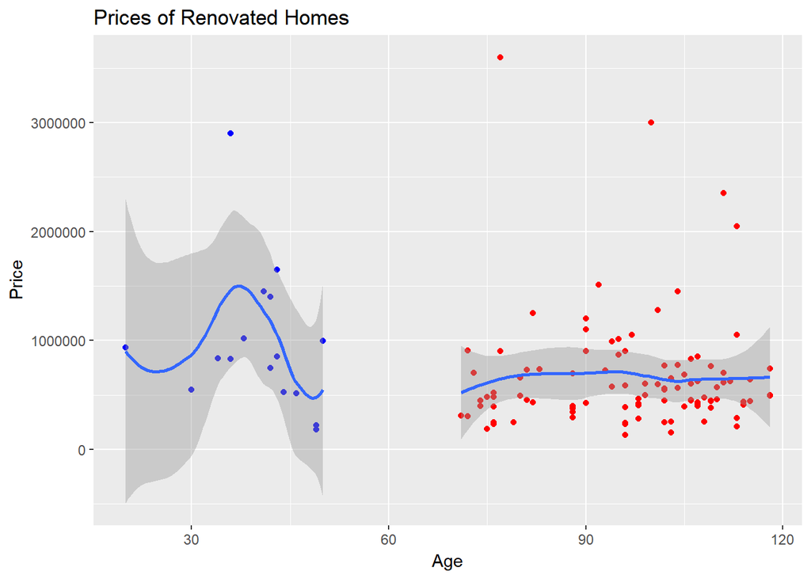

```r
#plot both graphs at the same time
  #newer plot
renovated_homes <- ggplot() +
  geom_point(data = subset(homes, homes$yr_renovated != 0 & homes$age < 51),
  aes(x = age, y = price), color = "blue") +
  geom_smooth(data = subset(homes, homes$yr_renovated != 0 & homes$age < 51),
  aes(x = age, y = price), method = "loess") +
  #older plot
  geom_point(data = subset(homes, homes$yr_renovated != 0 & homes$age > 69),
  aes(x = age, y = price), color = "red") +
  labs(title="Prices of Renovated Homes", x="Age", y="Price") +
  geom_smooth(data = subset(homes, homes$yr_renovated != 0 & homes$age > 69),
  aes(x = age, y = price), method="loess")

renovated_homes
```

One of the most interesting discoveries I made during the exploration was the effect that remodeling a home could have on the price. I segmented the dataset into two groups - a lower half containing newer homes between the ages of 1-50 and an upper half containing older homes between the ages of 70-120. When both scatterplots are graphed simultaneously, you can see there’s much more variance in price with the newer homes and there’s a much higher frequency in the group of older homes. This makes sense. Older homes typically would need additional repairs or new fixtures throughout the home to increase the value and make it easier to sell in the future. What’s interesting about this graph is that there’s 5 homes listed above $2 million - 4 of those homes being of the older type and 1 of them being a newer home. There’s only 30 homes in the entire dataset that are worth more than $2 million and if 4 of the 30 are older renovated homes, that accounts for 13%. This finding is promising for me during my house hunt because now I understand that newer homes aren’t necessarily the only way to build equity. Yes, they certainly will save money on home repairs and remodeling and reduce the stress of renovation, but if I can find an older home for a good deal, I know that I can invest in renovatiations that will ultimately increase the value of my home.

### Plot Two

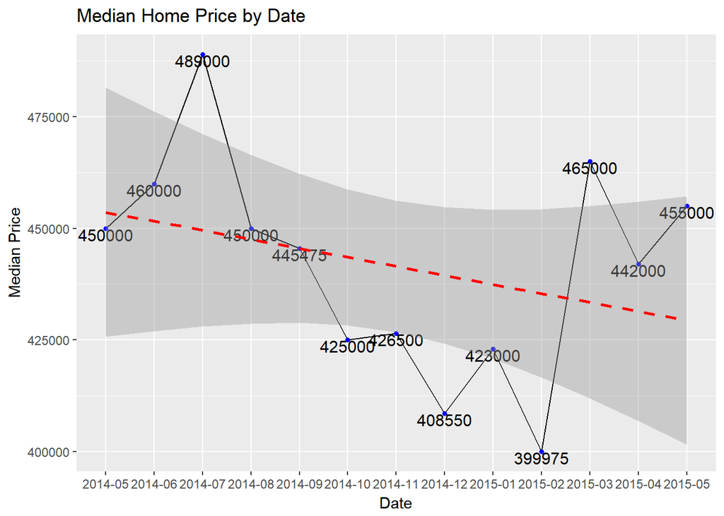

```r
#graph the median home price by month
ggplot(data=grouped_homes_by_month, aes(x = date1, y = median_home_price,
                                        group = 1)) +
  geom_line(stat="identity") +
  geom_point(shape=16, size=1, fill="red", colour="blue", stroke=1) +
  geom_text(aes(x=date1, label=median_home_price), size=4, vjust=1, hjust=.5) +
  labs(x='Date', y='Median Price', title='Median Home Price by Date') +
  geom_smooth(method = "lm", colour="red", linetype="dashed")
```

I chose this graph because as a future home owner it is important to understand trends in the housing market, that way you can predict when the best time to sell your home will be. If May, June, and July show upward trends in price compared to the rest of the year, I can do further research into what factors could be contributing to this. Maybe there’s an increase in families looking to move before the new school year starts for their kids which causes the demand in the market to increase and swings the selling leverage over to homeowners. If this ends up being true, it would be beneficial to me to put more emphasis on where my future home is located in proximity to great schools.

### Plot Three

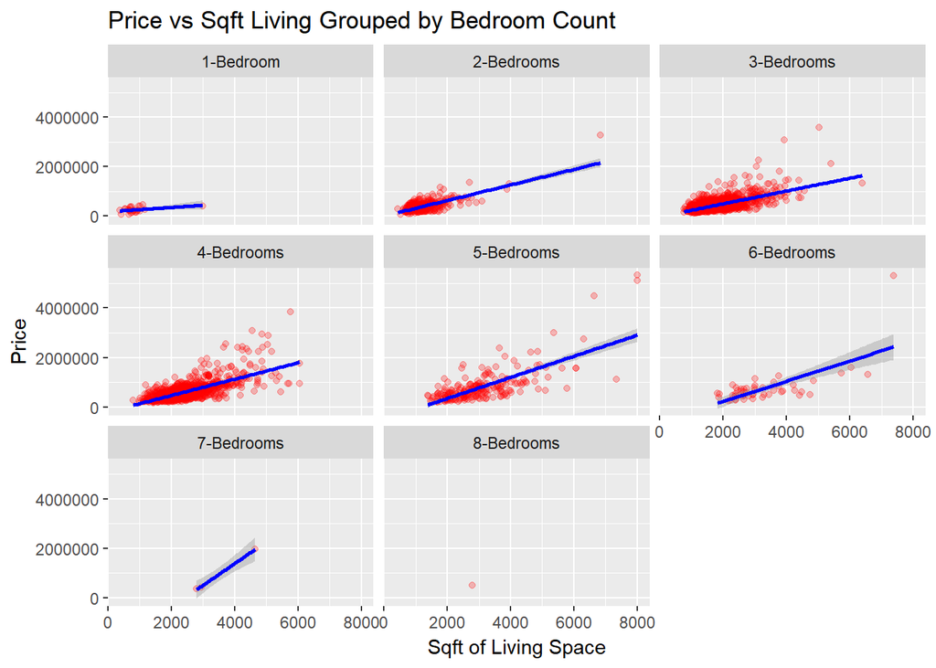

```r
bedroom_names <- c(
                    '1' = "1-Bedroom",
                    '2' = "2-Bedrooms",
                    '3' = "3-Bedrooms",
                    '4' = "4-Bedrooms",
                    '5' = "5-Bedrooms",
                    '6' = "6-Bedrooms",
                    '7' = "7-Bedrooms",
                    '8' = "8-Bedrooms"
                    )

# price vs sqft_living grouped by bedroom count
ggplot(homes, aes(sqft_living, price)) +
  geom_point(color = "red", alpha = 1/4) +
  facet_wrap(~bedrooms, labeller = as_labeller(bedroom_names)) +
  geom_smooth(method = "lm", colour="blue") +
  labs(x = "Sqft of Living Space", y = "Price",
  title = "Price vs Sqft Living Grouped by Bedroom Count")
```

I chose this as my last plot of interest because at the end of my exploration, I concluded that the biggest inflencing factor on home price was living square footage and this graph further clarifies that notion. No matter the number of bedrooms a house offers, the living square footage will still have the highest correlation to an increasing price compared to all other variables.

All in all, if I needed to make a choice as to what home to buy, I would choose a 4-bedroom home anywhere in the range of zipcodes and if the age of the home is on the higher end of the scale, I would make sure that it was recently renovated within the last 20 years. If I ever decided to sell this home, I would do it during the summertime, as I would get the most value out of my property.

# Reflection

After working with univariate, bivariate, and multivariate plots, I feel that each had it’s own benefits. It’s probably meant to be this way, but I found myself creating a univariate plot based off of one idea, but then that quickly segued into another question that needed to be explored using a bivariate plot, and then that quickly became a multivariate plot. It reminded me of creating layers to a photoshopped image - eventually the final graphic would display a well detailed picture.

I definitely need more practice but overall I feel that I have improved my visualization skills. The most difficult or tricky part I faced was figuring out if I should work within or outside of an aesthetic. After many trial- and-error attempts, I eventually would figure it out. Speaking of figuring things out, I was happy that I figured out how to account for outliers which helped me decide on using the median rather than the average during some of the exploration.

In the future, I would like to explore the idea of extrapolating the data for the plots where I grouped them by Month. The dataset only contained values for one year but if I truly wanted to create a more precise model of what the best time of year to sell a home would be, I would need to include data for many years. Earlier I touched on the notion of schools potentially playing a factor in home prices, so I would also like to explore that avenue and possibly import data related to schools.